# Análisis municipal de la renta

# XGBOOST:

XGBoost o Extreme Gradient Boosting, es uno de los algoritmos de machine learning de tipo supervisado más usados en la actualidad. Este algoritmo se caracteriza por obtener buenos resultados de predicción con relativamente poco esfuerzo, en muchos casos equiparables o mejores que los devueltos por modelos más complejos computacionalmente, en particular para problemas con datos heterogéneos. XGBoost es una herramienta muy útil para un data scientist y cuenta con implementaciones para diferentes lenguajes y entornos de programación.

Buscamos los mejores hiperparámetros.

Entrenamos el modelo y buscamos los mejores hiperparámetros.

Los mejores hiperparámetros son :

|  | nrounds | max_depth | eta | gamma | colsample_bytree | min_child_weight | subsample |
| --- | --- | --- | --- | --- | --- | --- | --- |
| 17 | 100 | 15 | 0.1 | 0 | 0.8 | 1 | 1 |

Calculamos el error cuadrático medio

```
## The root mean square error of the test data is  0.707
```

Y el R-cuadrado

```
## The R-square of the test data is  -0.28
```

Asimismo, hacemos la matriz de confusión y la normalizada del modelo

```
##              predicciones
## observaciones  1  2  3
##             1 16  6  1
##             2  2  0  1
##             3  0  0  0
```

```
##              predicciones
## observaciones    1    2    3
##             1 61.5 23.1  3.8
##             2  7.7  0.0  3.8
##             3  0.0  0.0  0.0
```

```
## El accuracy de XGBoost es de  61.5 %
```

Y mostramos la importancia relativa de las variables.

```
## xgbTree variable importance
##
##   Overall
## 5  100.00
## 7   72.67
## 6   63.59
## 1   63.55
## 4   60.43
## 2   49.70
## 3   32.82
## 0    0.00
```

Y mostramos la importancia relativa de las variables en el modelo Xgboost.

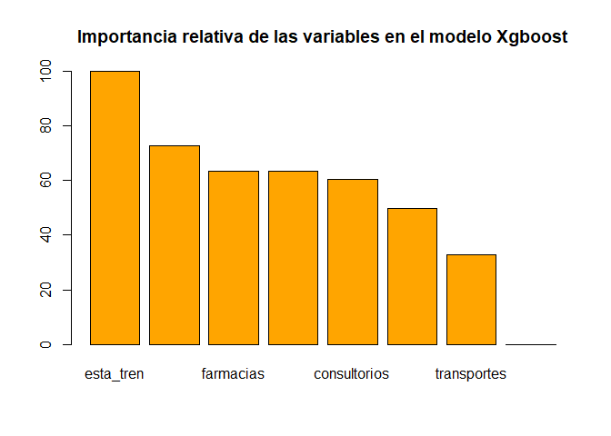

|  | 5 | 7 | 6 | 1 | 4 | 2 | 3 | 0 |
| --- | --- | --- | --- | --- | --- | --- | --- | --- |
| Overall | 100 | 72.66769 | 63.59143 | 63.55317 | 60.42676 | 49.70103 | 32.81942 | 0 |

[figure not shown]

## 7. Conclusiones.

Seguidamente, elaboraremos una tabla que contenga los accuracies de los distintos modelos para seleccionar el modelo que mayor precisión tenga. Que será con el que posteriormente hagamos nuestro shiny leaflet.

| Precisión |
| --- |
| 0.6153846 |
| 0.6538462 |
| 0.6538462 |
| 0.6153846 |

```
##              predicciones
## observaciones    1    2    3
##             1 53.8 15.4  3.8
##             2 11.5  7.7  0.0
##             3  3.8  0.0  3.8
```

Escogemos, el modelo porque tiende a clasificar mejor las rentas bajas, que el modelo qda, que es lo que predomina en nuestro dataset.

```
##              predicciones
## observaciones    1    2    3
##             1 61.5 19.2  3.8
##             2  7.7  3.8  3.8
##             3  0.0  0.0  0.0
```

Por último, elaboramos una shiny app donde mostramos los municipios, en términos de renta real y predicción.